Indicadores migratorios  
Fiji

[Observatorio Permanente de la Inmigración (OPI) - S.G de Análisis Migratorio (SGAM)](https://inclusion.seg-social.es/web/opi/estadisticas)

Junio 2023

1. Ciudadanos con documentación de residencia en vigor

2. Ciudadanos con otro tipo de documentación

3. Perfil sociodemográfico y distribución territorial

4. Afiliación en alta laboral y paro registrado

5. Nacionalizados españoles por residencia

6. Solicitantes de Protección Internacional

7. Beneficiarios del Sistema de Acogida y del programa de Atención Humanitaria

8. Menores extranjeros no acompañados y jóvenes extutelados (de 16 a 23 años)

9. Evolución de los flujos regulares (visados y documentación de residencia)

10. Población española residente en Fiji

# 1. Ciudadanos con documentación de residencia en vigor

A fecha 31/12/2022 no constaba ninguna persona de nacionalidad fiyiana con documentación de residencia en vigor en España.

Fuente: [OPI-SGAM](https://inclusion.seg-social.es/web/opi/estadisticas/catalogo/extranjeros_con_certificado)

**En la UE, España ocupa el puesto 13 en número de extranjeros documentados de Fiji**, según datos de Eurostat de finales de 2021.

Nacionales de Fiji con permiso de residencia en cada país de la UE/AELC según tiempo de validez del permiso. 31/12/2021

| Orden | País UE/AELC | TOTAL | De 3 a 5 meses | De 6 a 11 meses | 1 año o más |
| --- | --- | --- | --- | --- | --- |
| 1 | Francia | 297 | 1 | 42 | 254 |
| 2 | Alemania | 55 | 0 | 0 | 55 |
| 3 | Suiza | 32 | 0 | 0 | 32 |
| 4 | Italia | 31 | 0 | 0 | 31 |
| 5 | Suecia | 28 | 0 | 1 | 27 |
| 6 | Irlanda | 18 | 0 | 5 | 13 |
| 7 | Países Bajos | 15 | 0 | 0 | 15 |
| 8 | Rumanía | 12 | 0 | 1 | 11 |
| 9 | Noruega | 9 | 0 | 0 | 9 |
| 10 | Austria | 8 | 0 | 0 | 8 |
| 11 | República Checa | 7 | 0 | 0 | 7 |
| 12 | Dinamarca | 7 | 0 | 0 | 7 |
| 13 | España | 7 | 0 | 0 | 7 |
| 14 | Bélgica | 6 | 0 | 0 | 6 |
| 15 | Hungría | 4 | 0 | 1 | 3 |
| 16 | Malta | 4 | 1 | 1 | 2 |
| 17 | Grecia | 3 | 0 | 0 | 3 |
| 18 | Portugal | 3 | 0 | 0 | 3 |
| 19 | Finlandia * | 2 | : | : | 2 |
| 20 | Bulgaria | 1 | 0 | 0 | 1 |
| 21 | Estonia | 1 | 0 | 0 | 1 |
| 22 | Liechtenstein | 1 | 0 | 0 | 1 |
| 23 | Polonia | 1 | 0 | 0 | 1 |
| 24 | Eslovenia | 1 | 0 | 0 | 1 |
| 25 | República Eslovaca | 1 | 0 | 0 | 1 |
| 26 | Chipre | 0 | 0 | 0 | 0 |
| 27 | Croacia | 0 | 0 | 0 | 0 |
| 28 | Lituania | 0 | 0 | 0 | 0 |
| 29 | Luxemburgo | 0 | 0 | 0 | 0 |
| 30 | Letonia | 0 | 0 | 0 | 0 |
| - | Islandia | : | : | : | : |

(*) dato de 2020; (:) dato no disponible

Nota: el número de extranjeros con documentación de residencia publicado por OPI-SGAM y el de extranjeros con permiso de residencia publicado por Eurostat no coinciden por tratarse de diferentes estadísticas e incluir cada una de ellas diferentes tipos de documentación de extranjería.

Fuente: [Eurostat](https://ec.europa.eu/eurostat/databrowser/view/migr_resvalid/default/table?lang=en)

# 2. Ciudadanos con otro tipo de documentación

2.1 Personas con autorización de estancia por estudios

A 31/12/2022 constaban **4 nacionales de Fiji documentados con una autorización de estancia por estudios**, 75% hombres y 25% mujeres.

| Tipo de solicitante | TOTAL | Hombres | Mujeres |
| --- | --- | --- | --- |
| TOTAL | 4 | 3 | 1 |
| Estudiante | 4 | 3 | 1 |
| Familiar | 0 | 0 | 0 |

Fuente: [OPI-SGAM](https://inclusion.seg-social.es/web/opi/estadisticas/catalogo/extranjeros_estudios)

2.2 Solicitantes de asilo pendientes de resolución

La información publicada en la web pública de Eurostat indica que, a 30/04/2023 (último dato disponible), no había ninguna personas de nacionalidad fiyiana con la solicitud de Protección Internacional pendiente de resolución.

Fuente: [Eurostat](https://ec.europa.eu/eurostat/databrowser/view/migr_asypenctzm/default/table?lang=en)

2.3 Empadronados

A fecha de 01/01/2022, la más reciente con datos publicados para Fiji, **constaban empadronados 11** nacionales de dicho país.

Y a fecha de 31/12/2021 no habría ninguna persona documentada como residente, estudiante o solicitante de asilo pendiente de resolución, lo que sugiere que 11 personas de nacionalidad fiyiana podrían residir en España en aquel momento sin documentación de extranjería en vigor, el 100% del colectivo.

| Documentación | Personas |
| --- | --- |
| Empadronados a 01/01/2022 | 11 |
| Con documentación de residencia a 31/12/2021 | 0 |
| Con autorización de estancia por estudios a 31/12/2021 | 0 |
| Solicitantes de asilo pendiente de resolución a 31/12/2021 | 0 |
| Empadronados menos documentados | 11 |

Fuente: [Padrón Continuo - INE](https://www.ine.es/dyngs/INEbase/es/operacion.htm?c=Estadistica_C&cid=1254736177012&menu=ultiDatos&idp=1254734710990); [OPI-SGAM](https://inclusion.seg-social.es/web/opi/estadisticas/catalogo); [Eurostat](https://ec.europa.eu/eurostat/databrowser/view/migr_asypenctzm/default/table?lang=en)

# 3. Perfil sociodemográfico y distribución territorial

A fecha 31/12/2022 no constaba ninguna persona de nacionalidad fiyiana con documentación de residencia en vigor en España.

Fuente: [OPI-SGAM](https://inclusion.seg-social.es/web/opi/estadisticas/catalogo/extranjeros_con_certificado)

# 4. Afiliación en alta laboral y paro registrado

4.1 Régimen de afiliación a la Seguridad Social de nacionales de Fiji a 28/04/2023

En España hay **15 afiliados de Fiji**, que representan un 0% del total de ciudadanos de países no UE/AELC en alta laboral. 8 (53%) son hombres y 7 (47%) mujeres.

| Régimen | Afiliados de Fiji | Afiliados no UE/AELC | % Fiji sobre no UE/AELC |
| --- | --- | --- | --- |
| TOTAL | 15 | 1.745.903 | 0 |
| Régimen General | 13 | 879 | 1 |
| R.G. - S.E. Empleados/as hogar | 2 | 10 | 20 |
| R.E. Autónomos/as | 0 | 412 | 0 |
| R.E. Mar (cuenta ajena) | 0 | 2 | 0 |
| R.G. - S.E. Agrario | 0 | 9 | 0 |

Afiliados nacionales de Fiji en alta laboral según régimen y sexo. 28/04/2023

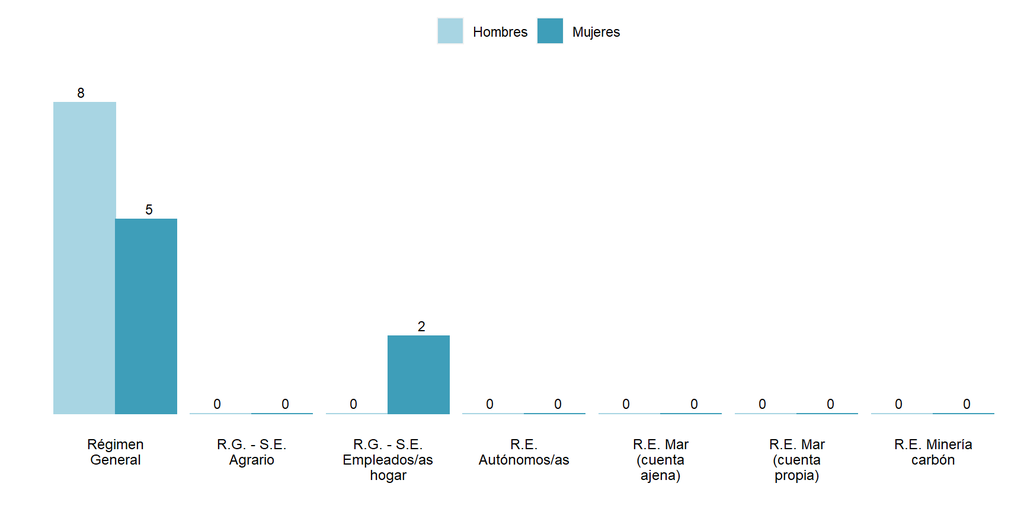

Fuente: [Seguridad Social - MISSM](https://www.seg-social.es/wps/portal/wss/internet/EstadisticasPresupuestosEstudios/Estadisticas/EST8/EST10/EST305/EST307/EST314)

4.2 Parados registrados en el SEPE nacionales de Fiji (abril 2023)

No hay ningua persona de Fiji registrada como parada en España.

Fuente: [Servicio Público de Empleo Estatal (SEPE)](https://www.sepe.es/HomeSepe/que-es-el-sepe/estadisticas.html)

# 5. Nacionalizados españoles por residencia

Además de la adquisición originaria, el Código Civil considera diferentes modos de **adquisición de la nacionalidad española**:

- **Por adopción**: los extranjeros menores de 18 años adoptados por un español.
- **Por opción**:  
  - Las personas que estén o hayan estado sujetas a la patria potestad de un español.  
  - Las personas cuyo padre o madre hubiera sido originariamente español y nacido en España.  
  - Las personas cuya filiación (identificación de quiénes son sus progenitores) o nacimiento en España se determine después de haber cumplido los 18 años.  
  - Los extranjeros mayores de 18 años adoptados por un español.
- **Por carta de naturaleza**: otorgada discrecionalmente mediante Real Decreto cuando en el interesado concurran circunstancias especiales.
- **Por residencia**, otorgada por el Ministerio de Justicia cuando concurran los siguientes requisitos:  
  1. Haber residido en España un plazo de tiempo que varía según el supuesto.  
  2. La residencia debe ser legal, continuada e inmediatamente anterior a la solicitud.  
  3. El interesado deberá justificar buena conducta cívica y suficiente grado de integración en la sociedad española.
- **Posesión de Estado**: posesión y utilización continuada de la nacionalidad española durante diez años con buena fe y basada en un título inscrito en el Registro Civil.

El 81% del total de adquisiciones de nacionalidad española (no originaria) registradas en el Registro Civil desde 2013 han sido por residencia. En 2022, último periodo publicado por el INE, ese porcentaje fue del 87%.

**Desde 2009 se han nacionalizado españoles por residencia un total de 2 personas con nacionalidad previa fiyiana.**

En 2022 no obtuvo la nacionalidad por residencia ninguna persona.

Evolución de las concesiones de nacionalidad española por residencia a ciudadanos de Fiji. 2009─2022

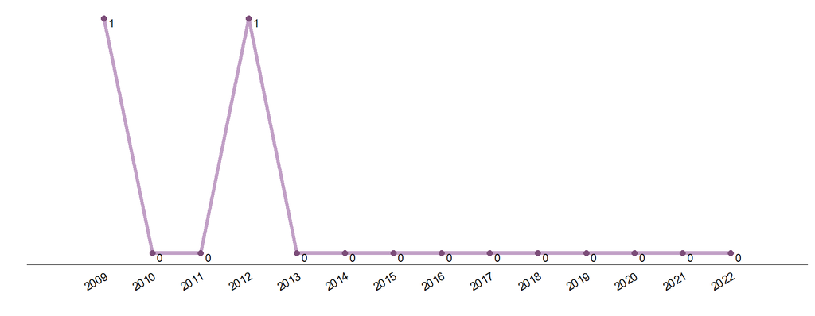

Fuente: [INE](https://www.ine.es/dyngs/INEbase/es/operacion.htm?c=Estadistica_C&cid=1254736177001&menu=resultados&idp=1254735573002), [OPI-SGAM](https://inclusion.seg-social.es/web/opi/estadisticas/catalogo/concesiones_nacionalidad)

# 6. Solicitantes de Protección Internacional

**De 2017 a 2022 ninguna persona nacional de Fiji ha solicitado Protección Internacional** en el territorio de España, ni en embajadas españolas, puestos fronterizos ni CIE.

Según avance mensual, **de enero a mayo de 2023 no hubo solicitudes de Protección Internacional de personas con nacionalidad fiyiana.**

De 2017 a 2022 no se resolvió ninguna solicitud de Protección Internacional de personas con nacionalidad fiyiana.

Fuente: [Oficina de Asilo y Refugio - Ministerio del Interior](https://www.interior.gob.es/opencms/es/servicios-al-ciudadano/tramites-y-gestiones/oficina-de-asilo-y-refugio/datos-e-informacion-estadistica/)

# 7. Beneficiarios del Sistema de Acogida y del programa de Atención Humanitaria

Actualmente no hay ninguna persona nacional de Fiji en el Sistema de Acogida para Refugiados, Inmigrantes y Solicitantes de Asilo ni en plazas de Atención Humanitaria.

Fuente: elaborado por SGAM-OPI a partir de información de la aplicación SIRIA (Sistema de Información sobre Programas para Refugiados, Inmigrantes y Solicitantes de Asilo) del [MISSM](https://inclusion.seg-social.es/web/migraciones/acogida-y-atencion-humanitaria)

# 8. Menores extranjeros no acompañados y jóvenes extutelados (de 16 a 23 años)

A 30/11/2022 no había ningún menor no acompañado o joven extutelado, de 16 a 23 años, de nacionalidad fiyiana con autorización de residencia en vigor.

Fuente: [OPI-SGAM](https://inclusion.seg-social.es/web/opi/estadisticas/catalogo/menores)

# 9. Evolución de los flujos regulares (visados y documentación de residencia)

9.1 Flujo de visados

Evolución de visados concedidos a ciudadanos de Fiji según clase de visado. 2013─2022

| Clase | 2013 | 2014 | 2015 | 2016 | 2017 | 2018 | 2019 | 2020 | 2021 | 2022 | % 2022 |
| --- | --- | --- | --- | --- | --- | --- | --- | --- | --- | --- | --- |
| TOTAL | 42 | 23 | 47 | 51 | 50 | 100 | 111 | 20 | 8 | 64 | 100 |
| Corta duración | 41 | 22 | 44 | 49 | 48 | 98 | 100 | 19 | 7 | 55 | 86 |
| Larga duración | 1 | 1 | 3 | 2 | 2 | 2 | 11 | 1 | 1 | 9 | 14 |
| Tránsito aeroportuario | 0 | 0 | 0 | 0 | 0 | 0 | 0 | 0 | 0 | 0 | 0 |

Evolución de visados concedidos a ciudadanos de Fiji según clase de visado de corta o larga duración. 2010─2022

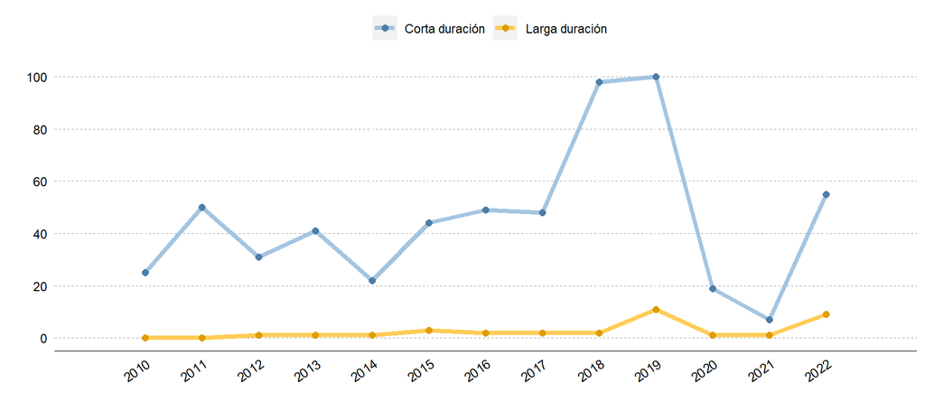

Visados expedidos a nacionales de Fiji según clase (corta o larga duración) y tipo/finalidad de visado. 2022

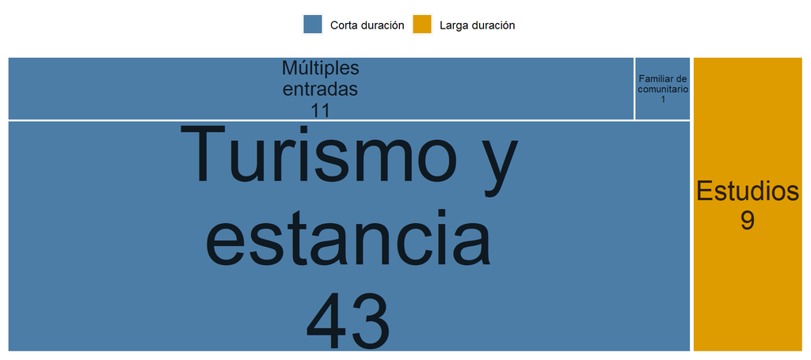

Fuente: [OPI-SGAM](https://inclusion.seg-social.es/web/opi/estadisticas/catalogo/visados)

Los visados de larga duración generalmente dan lugar a documentación de residencia.

9.2 Flujo de documentación de residencia

En los últimos 5 años se ha concedido o expedido documentación de residencia (autorizaciones de residencia o tarjetas de familiar de UE/AELC o de británico) a nacionales de Fiji por los siguientes motivos:

Autorizaciones de residencia concedidas a ciudadanos de Fiji según motivo. 2017─2021

[output not shown]

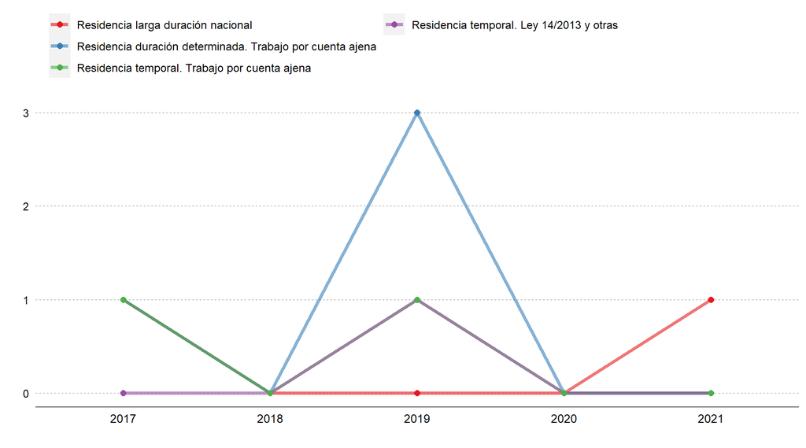

Tarjetas de familiar de ciudadano UE/AELC o TIE de familiar de británico beneficiario del acuerdo de retirada expedidas a nacionales de Fiji, según motivo. 2017─2021

| Motivo | 2017 | 2018 | 2019 | 2020 | 2021 |
| --- | --- | --- | --- | --- | --- |
| TOTAL | 1 | 0 | 0 | 0 | 1 |
| Familiar de UE-RU. Permanente | 0 | 0 | 0 | 0 | 1 |
| Familiar de UE-RU. Temporal | 1 | 0 | 0 | 0 | 0 |

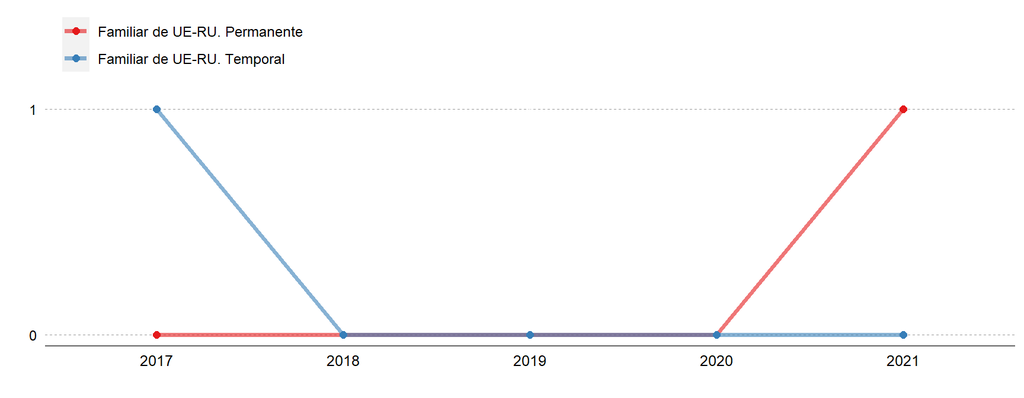

El siguiente gráfico muestra la **distribución de la documentación de residencia (autorizaciones de residencia o tarjetas de familiar de UE/AELC o de británico) concedida o expedida a nacionales de Fiji durante 2021, según tipo de trámite**:

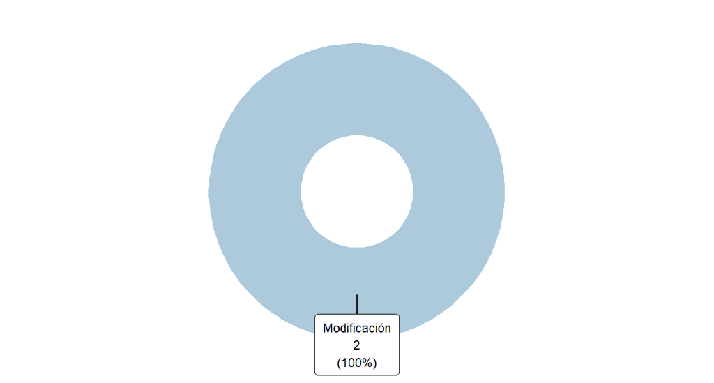

Fuente: [OPI-SGAM](https://inclusion.seg-social.es/web/opi/estadisticas/catalogo/flujo_autorizaciones)

**Comparando con el resto de países de la UE/AELC, el siguiente mapa muestra el número de *primeras* autorizaciones de residencia o de estancia por estudios expedidas a personas de nacionalidad fiyiana durante 2021**, entendiendo como *primera* aquella autorización concedida a una persona si no le fue concedida ninguna otra en los 6 meses anteriores.

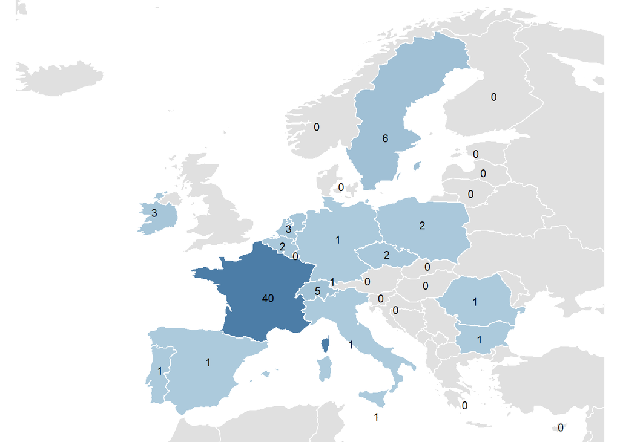

Sin dato disponible: Islandia

Fuente: [Eurostat](https://ec.europa.eu/eurostat/databrowser/view/migr_resfirst/default/table?lang=en)

# 10. Población española residente en Fiji

**A 01/01/2023, último dato publicado por el INE, había 6 españoles residentes en Fiji** inscritos en el fichero central del Padrón de españoles residentes en el extranjero (PERE); suponen el 0% de todos los españoles residentes en países de Oceanía.

| TOTAL | Hombres | % Hombres | Mujeres | % Mujeres |
| --- | --- | --- | --- | --- |
| 6 | 4 | 67 | 2 | 33 |

Evolución de los españoles residentes en Fiji inscritos en el PERE. 2009─2023

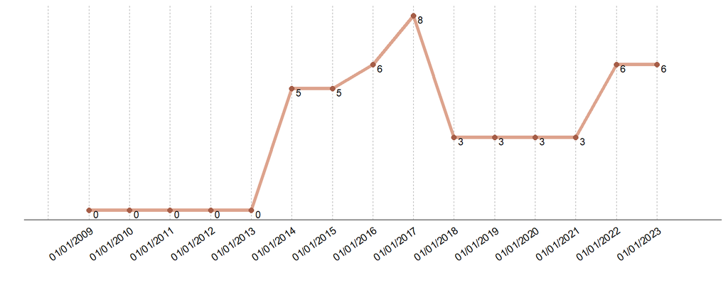

Fuente: [PERE - INE](https://www.ine.es/dyngs/INEbase/operacion.htm?c=Estadistica_C&cid=1254736177014&menu=resultados&secc=1254736195474&idp=1254734710990)